# HPLC data visualization

Donny Hoang

3/26/2020

## Goals

In lesson 2, most people correctly pointed out that COD measurements are limited because we do not know how specific compounds are changing. In this lesson, we will visualize HPLC data from the same experiment and try to better assess how the communities are behaving.

## Dataset

We are using the same dataset as the last two lessons, but here we are using High Performance Liquid Chromatograph (HPLC) data. Briefly, HPLC can identiy and quantify compounds of a liquid solution. However, this current dataset is still limited because we have only measured a small set of compounds. Unlike the previous dataset, we have data for every sample from every day of the experiment. Lastly, the compounds are expressed as grams/L in the datafile.

# Part 1: Load in packages and data.

```r
#Donny Hoang
#3.26.2020
#Graphing HPLC data

## if the packages are not installed, use these commands to install them
#install.packages('ggplot2')
#install.packages('reshape2')
#install.packages('ggpubr')
#install.packages('RColorBrewer')

library(ggplot2)
library(reshape2)
library(RColorBrewer)
library(ggpubr)
data<-read.csv("HPLC_CR.csv",header=TRUE)
```

Let’s take a quick look at the data. What compounds were measured?

```r
head(data)
```

```
##   Sample Treatment Replicate Day     Glucose    Xylose   Pyruvate    Xylitol
## 1 pH6_1A      pH 6         A   1 0.008984579 0.6556312 0.01625147 0.08534173
## 2 pH6_1B      pH 6         B   1 0.014645206 0.4245917 0.01725271 0.00000000
## 3 pH6_1C      pH 6         C   1 0.011016784 0.3111429 0.01777931 0.00000000
## 4 pH6_1D      pH 6         D   1 0.010146611 0.6742083 0.01997993 0.08112577
## 5 pH6_1E      pH 6         E   1 0.009916006 0.6827537 0.00000000 0.10896392
## 6 pH6_1F      pH 6         F   1 0.008654886 0.7047733 0.01965587 0.08871329
##     Succinate    Lactate   Glycerol     Formate   Acetate    Ethanol Cellobiose
## 1 0.004430737 0.13369223 0.04337623 0.004867212 0.7779366 0.00000000 0.00000000
## 2 0.002633407 0.04396264 0.03002779 0.000000000 0.3595236 0.00000000 0.00000000
## 3 0.005824199 0.05744762 0.03095145 0.000000000 0.3121196 0.00000000 0.00000000
## 4 0.003999708 0.09067183 0.04230154 0.007445813 0.8949222 0.00000000 0.00000000
## 5 0.004077648 0.23143624 0.05278046 0.000000000 0.7729899 0.09681288 0.08647779
## 6 0.005206588 0.08893598 0.04016782 0.015557680 1.1108060 0.00000000 0.00000000
```

```r
str(data)
```

```
## 'data.frame':    292 obs. of  15 variables:
##  $ Sample    : Factor w/ 292 levels "10%_g_1A","10%_g_1B",..: 196 197 198 199 200 201 202 98 99 100 ...
##  $ Treatment : Factor w/ 6 levels "pH 10","pH 6",..: 2 2 2 2 2 2 2 5 5 5 ...
##  $ Replicate : Factor w/ 7 levels "A","B","C","D",..: 1 2 3 4 5 6 7 1 2 3 ...
##  $ Day       : int  1 1 1 1 1 1 1 1 1 1 ...
##  $ Glucose   : num  0.00898 0.01465 0.01102 0.01015 0.00992 ...
##  $ Xylose    : num  0.656 0.425 0.311 0.674 0.683 ...
##  $ Pyruvate  : num  0.0163 0.0173 0.0178 0.02 0 ...
##  $ Xylitol   : num  0.0853 0 0 0.0811 0.109 ...
##  $ Succinate : num  0.00443 0.00263 0.00582 0.004 0.00408 ...
##  $ Lactate   : num  0.1337 0.044 0.0574 0.0907 0.2314 ...
##  $ Glycerol  : num  0.0434 0.03 0.031 0.0423 0.0528 ...
##  $ Formate   : num  0.00487 0 0 0.00745 0 ...
##  $ Acetate   : num  0.778 0.36 0.312 0.895 0.773 ...
##  $ Ethanol   : num  0 0 0 0 0.0968 ...
##  $ Cellobiose: num  0 0 0 0 0.0865 ...
```

# Part 2: Organizing the data.

Similar to the last lesson, our data is spread across 11 columns. Let’s melt() it into one column.

```r
data<-melt(data,id=c("Sample","Treatment","Replicate","Day"))
head(data) # quicklycheck that it worked
```

```
##   Sample Treatment Replicate Day variable       value
## 1 pH6_1A      pH 6         A   1  Glucose 0.008984579
## 2 pH6_1B      pH 6         B   1  Glucose 0.014645206
## 3 pH6_1C      pH 6         C   1  Glucose 0.011016784
## 4 pH6_1D      pH 6         D   1  Glucose 0.010146611
## 5 pH6_1E      pH 6         E   1  Glucose 0.009916006
## 6 pH6_1F      pH 6         F   1  Glucose 0.008654886
```

```r
str(data) #quickly check that it worked
```

```
## 'data.frame':    3212 obs. of  6 variables:
##  $ Sample   : Factor w/ 292 levels "10%_g_1A","10%_g_1B",..: 196 197 198 199 200 201 202 98 99 100 ...
##  $ Treatment: Factor w/ 6 levels "pH 10","pH 6",..: 2 2 2 2 2 2 2 5 5 5 ...
##  $ Replicate: Factor w/ 7 levels "A","B","C","D",..: 1 2 3 4 5 6 7 1 2 3 ...
##  $ Day      : int  1 1 1 1 1 1 1 1 1 1 ...
##  $ variable : Factor w/ 11 levels "Glucose","Xylose",..: 1 1 1 1 1 1 1 1 1 1 ...
##  $ value    : num  0.00898 0.01465 0.01102 0.01015 0.00992 ...
```

# Part 3: Graph the data

Since we have almost 300 samples, let’s focus on just Day 4 samples. That way, we can compare the data to our COD data and ask if it provides anymore information on how the communities are behaving. Let’s subset() the data, as we’ve done before.

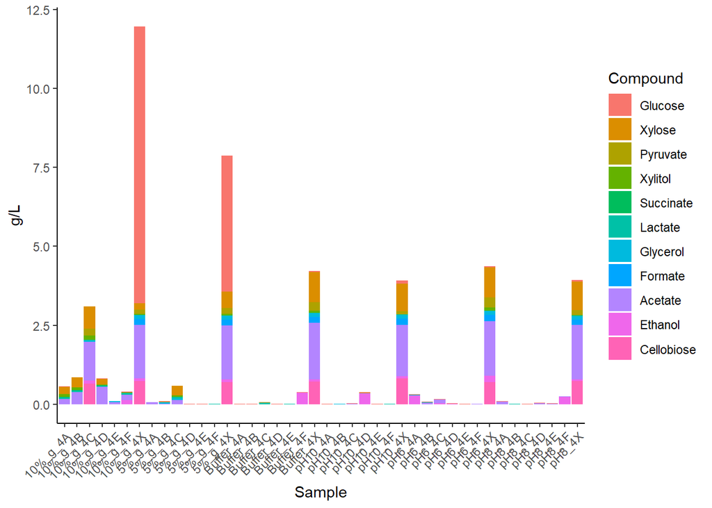

```r
day4 <- subset(data, data$Day=="4") #subset the data

p4 <-ggplot()+ #initialize the graph
           geom_bar(data=day4, aes(y=value,x=Sample,fill=variable),stat="identity") + #specify that we want a bar graph
           theme_classic() + #make it pretty
           theme(axis.text.x=element_text(angle=45, hjust=1)) + #rotate the x-axis labels so we can read it
           ylab("g/L") +  #add a descriptive y-axis label
           labs(fill='Compound') #change the legend title to be descriptive
p4
```

Before we start interpreting the data, I want to make a couple aesthetic changes. First, these colors aren’t great for representing our data. Having a gradient of colors for categorical variables can make interpretation difficult. Closeness in color can imply closeness in value - which doesn’t make sense for discrete categories. However, I don’t want to manually type in colors for all 11 of our compounds. We can get around this with RColorBrewer, which is a popular color palette package in R. Many of their color palettes are colorblind friendly (though we won’t be using one here because it doesn’t have enough colors for us).

Second, R has reordered all our samples alphabetically, which isn’t that useful for presenting our data in this situation.

Let’s tackle the colors first.

```r
colorCount <-length(unique(data$variable)) #count how many different colors we will need
getPalette = colorRampPalette(brewer.pal(11, "Set3")) #a function for getting our palette.
```

Can you figure out what the getPalette function is doing? Try Googling colorRampPalette() and brewer.pal(). Also, Set3 is my favorite color palette, but feel free to change it to [other palettes RColorBrewer has.](https://www.r-graph-gallery.com/38-rcolorbrewers-palettes.html) I recommend focusing on qualitative palettes for this dataset. Why would sequential or diverging palettes not work for our current data?

Next, R has automatically reordered our samples to be alphabetical. I don’t think this representation is useful, so we must reorder the samples ourselves. You’ve done factor reordering in previous lessons, so the code below may look familiar to you. Since the data is already “in order” in our original data file, that is the order I will have R order it.

```r
data$Sample <- factor(data$Sample, levels = unique(data$Sample)) # Tell R what order my samples go in
```

Now that we’re done with the aesthetic changes, let’s run our graph again.

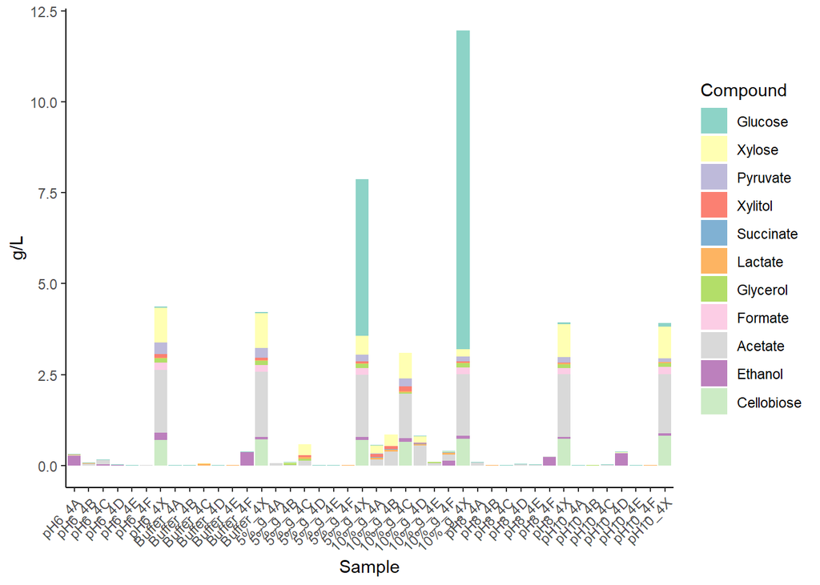

```r
day4 <- subset(data, data$Day=="4") #Our previous day4 object was not ordered, so subset again.

p4 <-ggplot()+ #initialize the graph
           geom_bar(data=day4, aes(y=value,x=Sample,fill=variable),stat="identity") + #specify that we want a bar graph
           theme_classic() + #make it pretty
           theme(axis.text.x=element_text(angle=45, hjust=1)) + #rotate the x-axis labels so we can read it
           ylab("g/L") +  #add a descriptive y-axis label
           labs(fill='Compound') + #change the legend title
           scale_fill_manual(values=getPalette(colorCount)) #add our specified color palette
p4
```

This graph looks better! At least to me, because our control treatment is listed first while our experimental treatments are listed next. Additionally, each color is distinct from its neighbor which makes identifying it in the graph easier. Let’s starting interpreting:

1. How do the controls (replicate X) look? Do they make sense given the treatment?
2. How do the inoculated samples look? How do they compare within treatment? Between treatments?
3. Does this data change any conclusions you made from the COD data?

# Part 4: Graph the remaining data.

We focused on Day 4 first because that’s the day we had COD data for. Let’s look at the remaining samples. Remember how we made a function that would graph our data in lesson one? Let’s revisit that skill.

```r
myplotmaker<- function(...){
  return(... %>%
           ggplot()+
           geom_bar(aes(y=value,x=Sample,fill=variable),stat="identity") +
           theme_classic() +
           theme(axis.text.x=element_text(angle=45, hjust=1)) +
           ylab("g/L") +
           labs(fill='Compound') +
           scale_fill_manual(values=getPalette(colorCount)))}
```

Let’s double check that this function works how we want. If it does, it should give us an identical plot to Day 4 graph we just made.

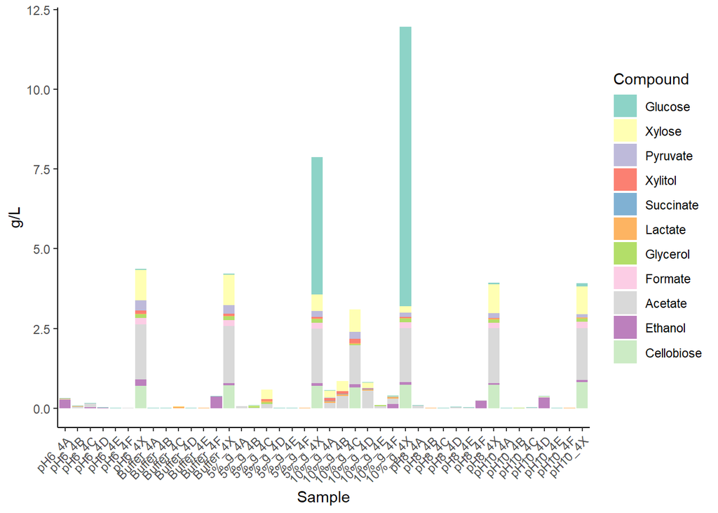

```r
p4 <- myplotmaker(day4)
p4
```

It does! Let’s do the rest.

```r
day1 <- subset(data, data$Day=="1")
p1<- myplotmaker(day1) +ggtitle("Day 1")
day2 <- subset(data, data$Day=="2")
p2<- myplotmaker(day2) +ggtitle("Day 2")
day3 <- subset(data, data$Day=="3")
p3<- myplotmaker(day3) +ggtitle("Day 3")
day4 <- subset(data, data$Day=="4")
p4<- myplotmaker(day4) +ggtitle("Day 4")
day5 <- subset(data, data$Day=="5")
p5<- myplotmaker(day5) +ggtitle("Day 5")
day6 <- subset(data, data$Day=="6")
p6<- myplotmaker(day6) +ggtitle("Day 6")
day7 <- subset(data, data$Day=="7")
p7<- myplotmaker(day7) +ggtitle("Day 7")
```

We have all our graphs made. We could put them all onto the same image, but it look squished.

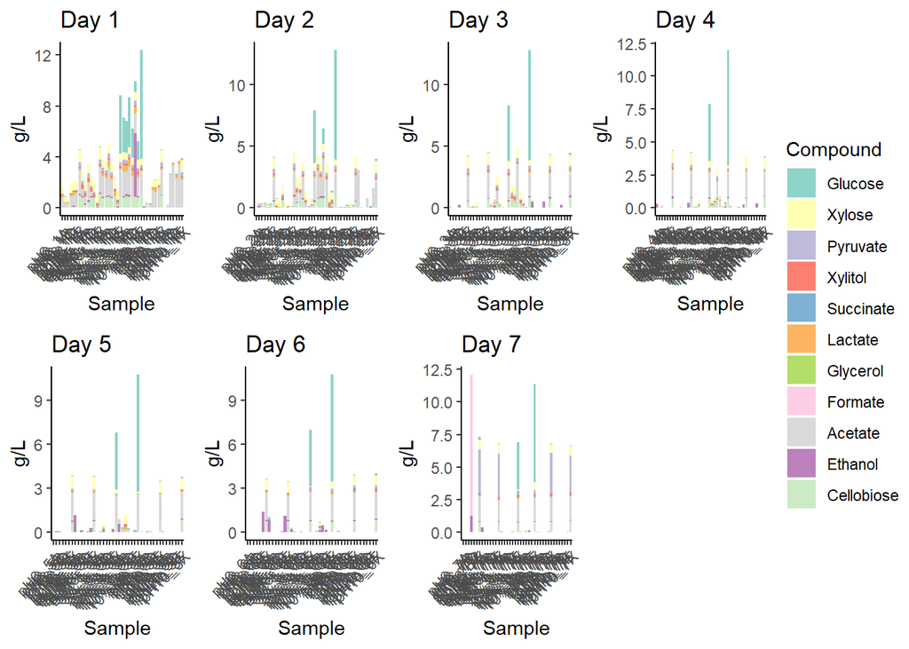

```r
ggarrange(p1, p2, p3, p4, p5, p6, p7, #add all the graphs we want
          ncol=4, nrow=2, # specify the number of columns and rows
          legend="right", # move the legend to the bottom
          common.legend=TRUE) # these graphs all have the same legend, so tell R that
```

This graph can be hard to interpret as is, but you can zoom into the plot on RStudio if you wish. Since this is an exploratory analysis, we could also look at each graph individually.

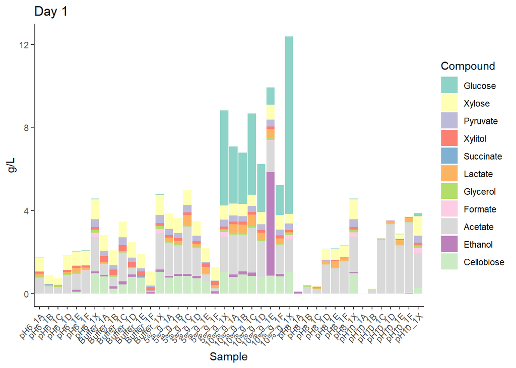

```r
p1
```

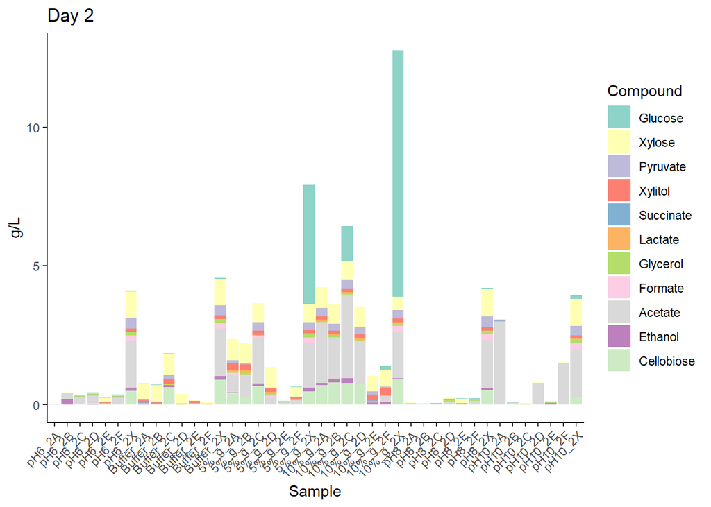

```r
p2
```

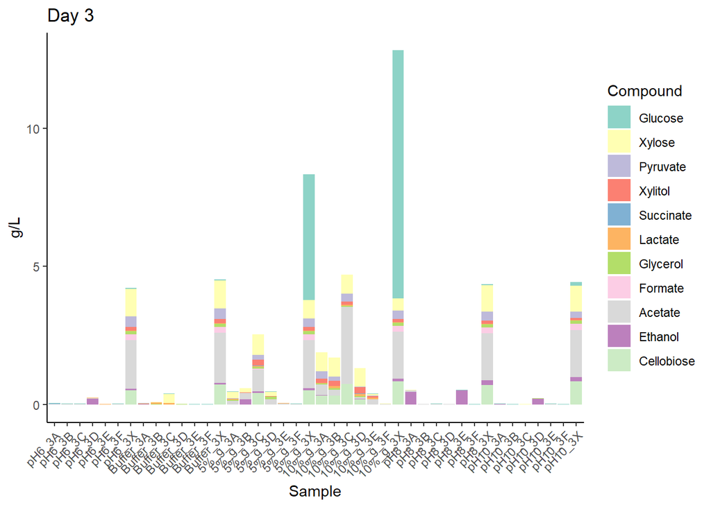

```r
p3
```

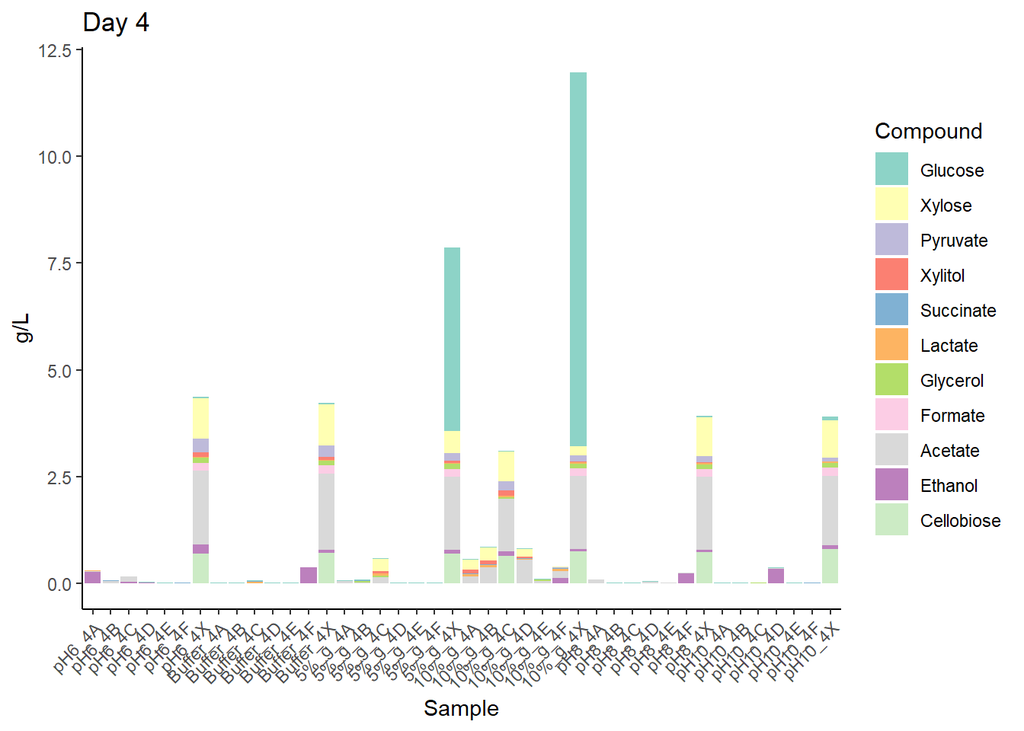

```r
p4
```

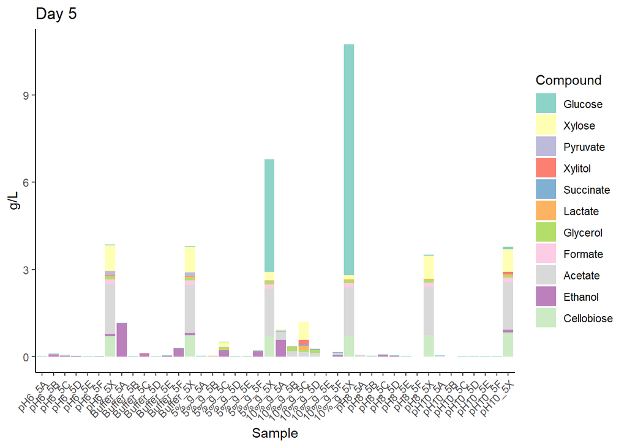

```r
p5
```

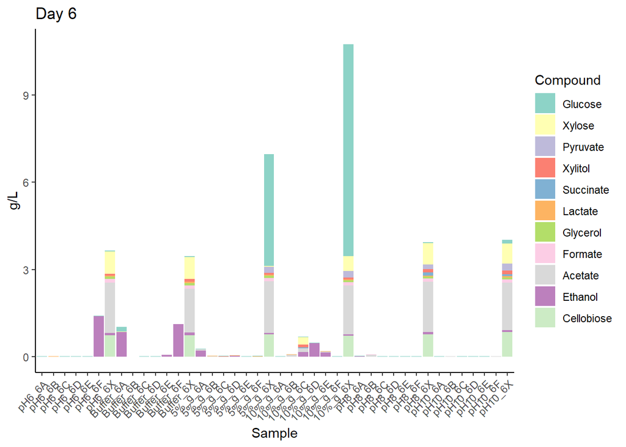

```r
p6
```

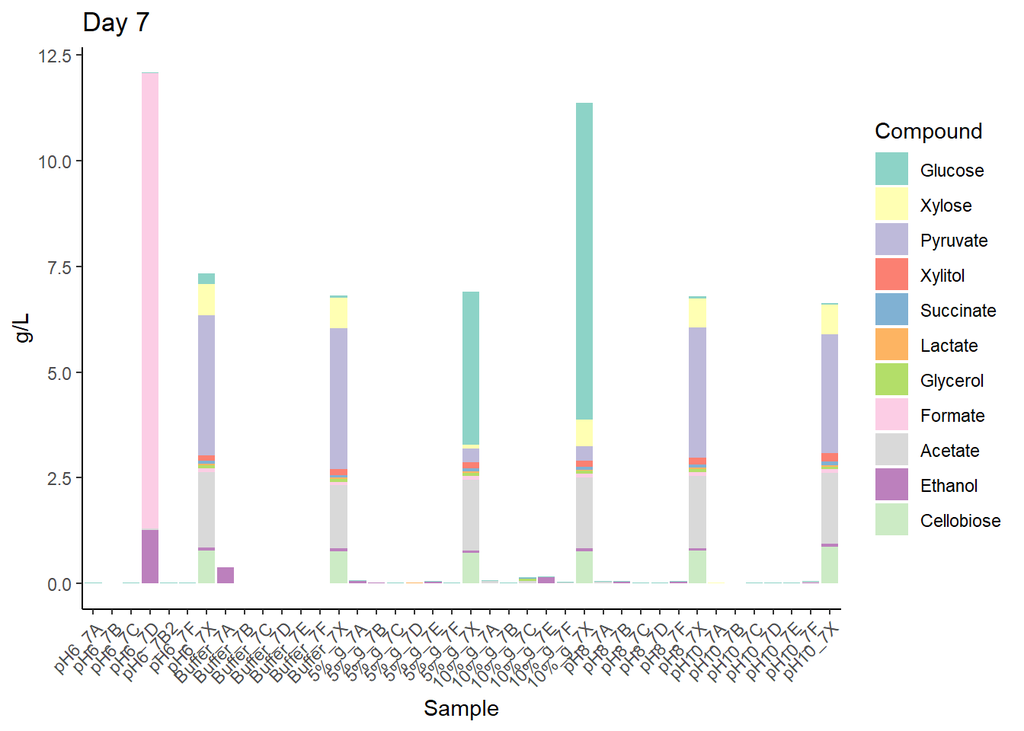

```r
p7
```

Whatever you chose to do, review the questions:

1. How do the controls look? Do they look the same across time?
2. Are there any samples that stand out to you? For example, are there any samples where the measured compounds don’t make sense?
3. Given your answer from 1 and 2, which samples should be sent back for re-analysis?
4. What biological conclusions can we take from this data? Are the communities behaving differently with the measured compounds based on their treatmeant?

I hope everyone is feeling more comfortable with R. Next week we will begin 16S amplicon sequence analysis with a dataset that was generated last year.